# Cluster analysis in practice

Grouping web texts by their dimension scores

Dr Massimiliano Canzi

# Cluster analysis in practice

`Did you know:` Mozart kept a pet starling for three years. In his account book, he wrote down a melody it sang, a variant of a theme from his Piano Concerto in G major, K. 453.

*Source: West & King (1990), American Scientist*

## How this session works

As in lectures 4, 6 and 9: you work on your own or in pairs, the task slides say what to do, checkpoints show what you should get, and the solutions are in the source of these slides, `source/11_cluster_analysis_practical.qmd` at github.com/mcanzi/advanced_statistics. The tutorial sheet for this session: `konstats::get_tutorial(11, ".", course = "advanced")`.

Today’s data hide a trap from lecture 10. See whether you find it before the slides point it out.

## The study

`web_registers` from {simling}, the 480 web texts from six registers of lecture 9. There, a factor analysis found three dimensions of variation, and the registers overlapped on all three.

The research question: do the texts fall into groups by their linguistic features, and do those groups match the six registers?

## The dimensions again

The factor analysis from lecture 9, without the redundant `pronouns`:

```r
features <- select(web_registers, adverbs:word_length, -pronouns)
mda <- fa(features, nfactors = 3, rotate = "promax", fm = "minres")
scores <- bind_cols(select(web_registers, text, register), as_tibble(mda$scores))
scores
```

```
# A tibble: 480 × 5
  text  register           MR1    MR3     MR2
  <fct> <fct>            <dbl>  <dbl>   <dbl>
1 T001  forum discussion 0.571 -0.635 -1.02
2 T002  forum discussion 1.99  -0.834  0.228
3 T003  forum discussion 0.349 -0.643  1.18
4 T004  forum discussion 2.07  -0.467 -0.0840
# ℹ 476 more rows
```

`?web_registers` gives the true model. Leave it closed until you have finished the tasks.

## Task 1: look at the scores

1. Look at the loadings with `print(mda$loadings, cutoff = 0.3, sort = TRUE)` and give each dimension the name you gave it in lecture 9
2. Plot every text on two of the dimensions, coloured by register. Do the registers form separate groups?
3. Compute the standard deviation of each dimension. Do the scores need standardising before clustering?

## Checkpoint 1

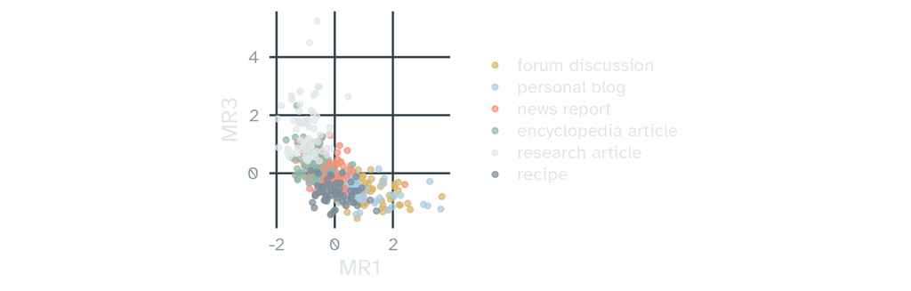

The registers have their own areas, but they overlap, and forum discussions and personal blogs share most of theirs. The scores have standard deviations a little below 1, so they are on similar scales already.

# Clustering the texts

`Did you know:` each starling in a flock adjusts its flight to six or seven of its nearest neighbours, however far away they are. This keeps a flock together when its density changes.

*Source: Ballerini et al. (2008), PNAS*

## Task 2: cluster the features

Why not cluster the texts on the 16 features directly?

```r
set.seed(1)
km_raw <- kmeans(features, centers = ___, nstart = 25)
```

- Fit k-means with four clusters on `features`
- Compute the mean of each feature per cluster. Which features differ most between the clusters?
- Compare these features with the standard deviations of all features. What has happened?

## Checkpoint 2

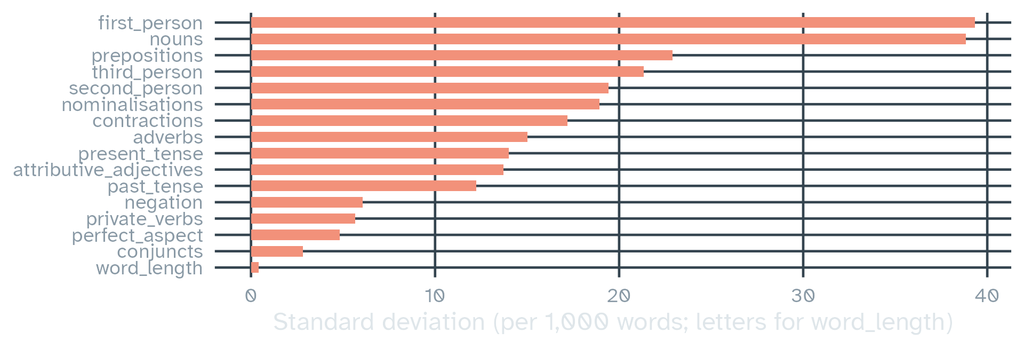

`first_person` and `nouns` vary most, so they decide the distances on the raw features, and `word_length`, with a standard deviation below 1, counts for almost nothing.

## The trap

On raw features, the clusters follow the features with the largest numbers. A rate per 1,000 words of nouns varies more than a rate of conjuncts because nouns are more frequent, which says nothing about how important nouns are for telling texts apart.

- Standardise the features with `scale()`, as in lecture 10, or
- cluster on the dimension scores, which summarise the shared variation of all features on a common scale. In a multi-dimensional analysis, these are the natural basis for grouping texts

## Task 3: how many clusters?

From now on, cluster the dimension scores:

```r
S <- as.matrix(select(scores, starts_with("MR")))
```

1. Compute the within-cluster sum of squares of k-means for k from 1 to 8, and plot it
2. Compute the average silhouette width for k from 2 to 8, with `silhouette()` from `{cluster}`, as in lecture 10
3. Which k would you choose? How strong is the structure?

## Checkpoint 3

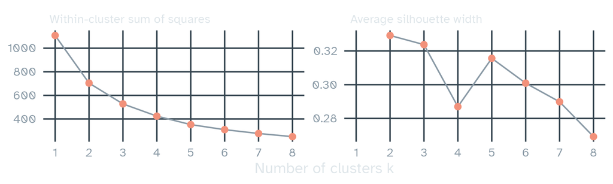

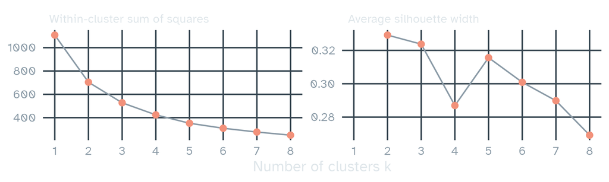

There is no clear elbow, and the average silhouette width stays between 0.27 and 0.33 for every k: weak structure, by Kaufman and Rousseeuw’s (1990) guide.

# Clusters and registers

`Did you know:` when one starling in a flock changes direction, the change is correlated with the movement of birds across the whole flock, in small flocks and in flocks of thousands alike.

*Source: Cavagna et al. (2010), PNAS*

## Task 4: three clusters

With no clear best k, the choice is yours. Take k = 3 for now.

1. Fit k-means with three clusters on `S`, with `set.seed(1)` and `nstart = 25`
2. Cross-tabulate the clusters with the registers. Which registers share a cluster, and which register is split?
3. Fit a Ward hierarchical clustering on the same scores, cut it into three clusters, and compare it with k-means

## Checkpoint 4

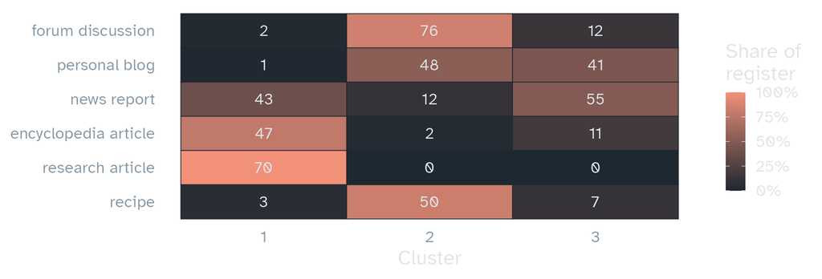

Your cluster numbers may differ. Research articles fall into one cluster with most encyclopedia articles, forum discussions with recipes, and news reports and personal blogs split across clusters.

## Task 5: describe the clusters

Describe a cluster by what its members share. The register most of them come from may not fit all of them.

1. Compute the mean score of each cluster on each dimension, and plot these profiles
2. Name each cluster from its profile, with the dimension names from Task 1
3. Would these names fit the registers that make up each cluster?

## Checkpoint 5

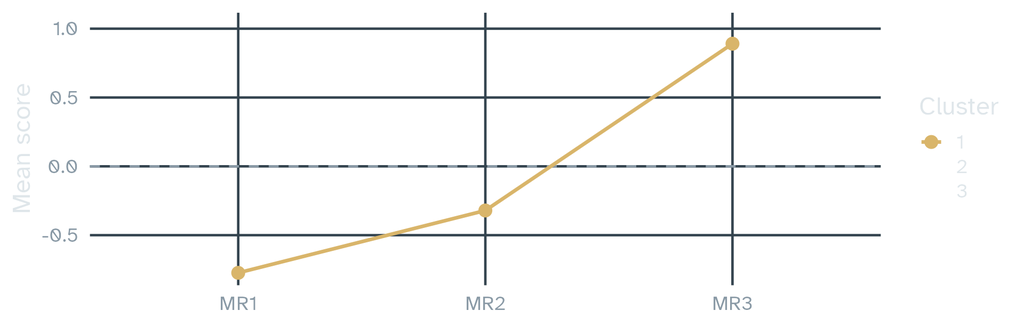

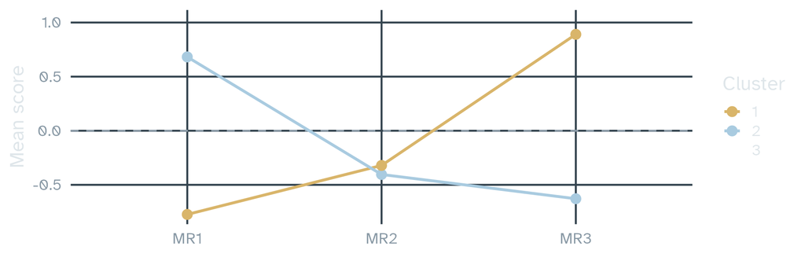

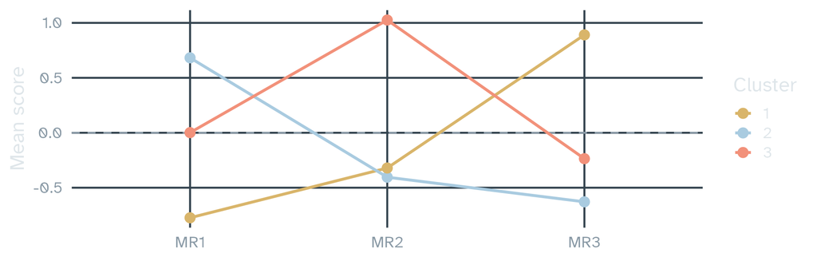

Each cluster stands out on one or two dimensions. Clusters that mix registers can still have a clear profile.

# How stable are the clusters?

`Did you know:` starlings learned to tell apart sound sequences built with centre-embedding from sequences without it. Gentner and colleagues saw this as recursive pattern learning; linguists have questioned whether the birds learned a recursive rule at all.

*Source: Gentner et al. (2006), Nature*

## Task 6: two halves

Clusters that come back in new data are more convincing. Split the texts at random into two halves, and cluster each half separately.

```r
set.seed(3)
half <- sample(rep(1:2, length.out = nrow(S)))
nearest <- function(X, centres) apply(X, 1, \(x) which.min(colSums((t(centres) - x)^2)))
```

1. Fit k-means with three clusters to each half
2. Assign all 480 texts to the nearest centre of each solution with `nearest()`, and compare the two assignments with the adjusted Rand index from lecture 10, `mclust::adjustedRandIndex()`
3. Repeat with k = 6. Which solution is more stable?

## Checkpoint 6

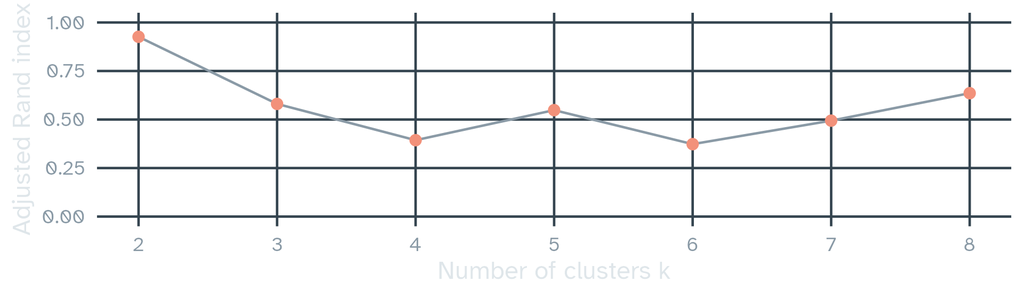

Agreement between the solutions of the two halves, corrected for chance. The adjusted Rand index is 0.58 for three clusters and 0.37 for six.

## Task 7: report

Write a short methods and results paragraph. It should say:

- what was clustered, and why you did not cluster the raw features
- the method, its settings and the seed, and how you chose k, with the silhouette widths
- how the clusters relate to the registers, how you named them, and how stable they were

Would a reviewer accept your number of clusters? If you work with others, swap paragraphs and check each other’s.

## If you finish early

- Open `?web_registers` and look at the true register means on the three dimensions. Which registers should be hardest to tell apart?
- Compute the mean dimension scores of the six registers, and cluster these six rows with `hclust()`. Draw the dendrogram with `plot()`. Which registers merge first?
- Fit `cluster::pam()` with three clusters and compare it with k-means

## Summary

- On raw features, the features with the largest variances decide the clusters: standardise, or cluster dimension scores
- With overlapping groups, elbow and silhouettes give no clear `k`, and the silhouette width shows how weak the structure is
- Compare clusters with known groups through a cross-table, and describe each cluster by its profile
- Check stability on random halves before you interpret a cluster solution

## References

- Biber, D. (1988). *Variation across speech and writing*. Cambridge University Press. https://doi.org/10.1017/CBO9780511621024
- Ehret, K., & Taboada, M. (2021). Characterising online news comments: A multi-dimensional cruise through online registers. *Frontiers in Artificial Intelligence*, 4, 643770. https://doi.org/10.3389/frai.2021.643770
- James, G., Witten, D., Hastie, T., & Tibshirani, R. (2021). *An introduction to statistical learning: With applications in R* (2nd ed.). Springer. Chapter 12. https://www.statlearning.com https://doi.org/10.1007/978-1-0716-1418-1
- Kaufman, L., & Rousseeuw, P. J. (1990). *Finding groups in data: An introduction to cluster analysis*. Wiley. https://doi.org/10.1002/9780470316801

## Sources of the animal facts

- Ballerini, M., Cabibbo, N., Candelier, R., Cavagna, A., Cisbani, E., Giardina, I., Lecomte, V., Orlandi, A., Parisi, G., Procaccini, A., Viale, M., & Zdravkovic, V. (2008). Interaction ruling animal collective behavior depends on topological rather than metric distance: Evidence from a field study. *PNAS*, 105(4), 1232–1237. https://doi.org/10.1073/pnas.0711437105
- Cavagna, A., Cimarelli, A., Giardina, I., Parisi, G., Santagati, R., Stefanini, F., & Viale, M. (2010). Scale-free correlations in starling flocks. *PNAS*, 107(26), 11865–11870. https://doi.org/10.1073/pnas.1005766107
- Gentner, T. Q., Fenn, K. M., Margoliash, D., & Nusbaum, H. C. (2006). Recursive syntactic pattern learning by songbirds. *Nature*, 440(7088), 1204–1207. https://doi.org/10.1038/nature04675
- West, M. J., & King, A. P. (1990). Mozart’s starling. *American Scientist*, 78(2), 106–114.

## Slides and code

[figure not shown]

These slides

mcanzi.de/advanced_statistics/11_cluster_analysis_practical.html

Code and all lectures

github.com/mcanzi/advanced_statistics